#### 01/2024

#### Máster de Ciencia de Datos de la UOC

# Estudio de técnicas para tratar el conjunto de datos desbalanceado

## Índice

- Inicialización de librerías
- Argumentación de métricas utilizadas
- Modelo base
- Estudio de estrategias para tratar el desbalance en los datos
- Estudio ratio entre clases

## Inicialización de librerías

En este notebook se trabaja con los datos del primer ciclo preparados para el tratamiento del desbalanceo

```python
from pyspark.sql.functions import *
from pyspark.sql.types import *
from pyspark.sql.window import Window
import seaborn as sns
import matplotlib.pyplot as plt
import pandas as pd
from pyspark.sql import SparkSession
from sklearn.model_selection import train_test_split, cross_val_score
from sklearn.model_selection import GridSearchCV, RepeatedStratifiedKFold
from sklearn.ensemble import RandomForestClassifier
from imblearn.pipeline import make_pipeline
from imblearn.under_sampling import RandomUnderSampler
from imblearn.over_sampling import RandomOverSampler, SMOTE, ADASYN
from sklearn.metrics import f1_score, recall_score, precision_score

# se inicia sesion de spark
spark = SparkSession.builder.appName('Read Files').getOrCreate()
```

```python
consolidacion = spark.read.parquet("/Archivos/consolidacion.parquet").drop("IDUSUARIO").toPandas()
```

## Argumentación de métricas utilizadas

Si se recuerda, al hacer el conteo de la variable objetivo, se encontraba que únicamente el 1.86% del total de usuarios pertenecen al subgrupo de clientes. Debido a esto, los modelos pueden tener problemas para predecir correctamente la clase objetivo, por lo que se tiene que hacer un tratamiento de estos datos desbalanceados. Además, en este tipo de conjuntos de datos, la exactitud (accuracy) no tiene mucho sentido, ya que se puede tener un conjunto de 100 valores, los cuales 99 pertenecen a una clase y 1 en otra. Al crear un modelo para predecir la clase minoritaria donde se asignan todos los valores a la clase mayoritaria, se obtiene una exactitud de un 99%, pero esto, aunque fuera correcto matemáticamente, sería erróneo en su razonamiento, ya que el modelo estaria sesgado a la clase mayoritaria y no clasificaria bien la clase minoritaria.

Por esta razón, para datos desbalanceados se tiene que utilizar otras métricas como la precisión, la sensibilidad (recall) y el F1 score. Estas métricas se obtienen a partir de la matriz de confusión que recoge los valores reales de los calculados. Se considera positivo a la clase minoritaria que es la que se quiere predecir y negativo a la clase mayoritaria.

|  | Positive Prediction | Negative Prediction |
| --- | --- | --- |
| Positive Class | True Positives (TP) | False Negatives (FN) |
| Negative Class | False Positives (FP) | True Negatives (TN) |

La **precisión** se calcula como la fracción de los valores positivos clasificados correctamente respecto a todos los que se han predicho como positivos. En otras palabras, se podría explicar con cómo de certero es la predicción de un modelo cuando asigna un punto a la clase positiva.

$$ precision = \frac{True Positives}{True Positives + False Positives} $$

El problema de esta métrica, aunque informativa, es que no contempla el total de valores positivos reales, únicamente de los valores que se han clasificado como positivos. Se podría tener un conjunto de 100 positivos reales y 1000 negativos reales, en el momento de hacer la predicción se podrían clasificar 60 como positivos, de los cuales 55 podrían ser positivos reales y 5 falsos positivos, obteniendo un valor de precisión de un 91%, que sería alto, el problema es que no tiene en cuenta los 40 positivos reales que habria clasificado como negativos, asi que no estaría dando toda la información.

El **recall** aplica otro enfoque, se calcula como la fracción de los valores positivos calculados correctamente respecto a todos los valores positivos reales que se han podido clasificar bien o erróneamente.

$$ recall = \frac{True Positives}{True Positives + False Negatives} $$

Esta métrica da una información más explicativa sobre toda la clase minoritaria. En el ejemplo anterior, el recall tendría un valor de 55%, muy inferior al 91% de la precisión, lo que estaria diciendo que el modelo tiene problemas para predecir la clase minoritaria. Por otro lado, se tiene que tener cuidado al maximizar el recall, ya que un modelo que clasifica todos los valores como la clase minoritaria y cero a la mayoritaria, estaría obteniendo un recall de 1, pero la precisión tenderia a cero ya que el valor de falsos positivos seria todo el subgrupo mayoritario.

Por todo lo anterior, la precision y el recall suelen estar en tensión, donde al aumentar el recall disminuye la precision y viceversa. En los datos del ecommerce, aumentar la precisión implicaria que no se estaria detectando los potenciales clientes, pero si se aumenta únicamente el recall se enviaria al departamento de marketing demasiados usuarios que no estarian interesados, aumentando los costes por tener que dedicar tiempo y dinero a usuarios no potenciales. El objetivo es mejorar el recall sin penalizar la precision, idealmente se quiere un recall y una precisión altos.

El **F1 score** combina las dos métricas anteriores en una sola. Como se ha visto, cada una no es capaz de explicar todo, por lo que al hacer una combinación se puede tener una estimación de todo el comportamiento del modelo. Esta métrica se define como la media armónica de las dos, por lo que si las dos métricas tienen valores cercanos a 1, el F1 score tenderá a tener valores altos, y si una de las dos tiene un valor bajo, el F1 score también bajará.

$$ F_1 = \frac{2 · precision · recall}{precision + recall} $$

En el caso del ejemplo, se obtendria un valor de 0.69 para un recall de 0.55 y una precision de 0.91. Por esto, es interesante maximizar el F1 score siempre teniendo en cuenta el recall para el caso de este proyecto. De esta forma, se puede mejorar el recall siempre que el F1 score sea estable o aumente, de esta forma aumentaria el recall sin perjudicar la precision.

## Modelo base

Una vez se han mostrado las métricas que se van a usar para comparar diferentes modelos. Antes de aplicar técnicas para el tratamiento del desbalance de los datos, se va a utilizar el modelo random forest como modelo base para ver de dónde se parte con el dataset elegido del primer ciclo. En este paso, se hacen unas consideraciones que serán utilizadas en todo el proceso de creación y cálculo de los resultados.

Primeramente, se hace una separación del dato aleatoria entre el subset de train y el de test. El de test se utilizará únicamente para comprobar cómo de bien predice el modelo con datos completamente nuevos. Si los resultados con el conjunto de test son peores que con los de validación, podría haber overfitting y no generalizaría bien, en cambio si son mejores significará que el modelo generaliza bien con datos nuevos.

Para separar los datos en los conjuntos de train y validación se puede hablar de dos estrategias, la aleatoria, donde se seleccionan registros aleatoriamente hasta que esten todos repartidos en los dos subgrupos, o la estratificada, la cual selecciona aleatoriamente los registros pero manteniendo la proporción entre la clase mayoritaria y minoritaria. Esta segunda estrategia es la recomendada para conjuntos de datos desbalanceados, ya que la proporción entre clases es importante para que el modelo tenga en cuenta esta casuística tanto en el entrenamiento, como en la validación, de esta forma generalizará mejor con datos nuevos en el conjunto de test.

Con toda esta información, se aplica random forest:

```python
X = consolidacion.drop(columns=['IND_CLIENTE','IDUSUARIO'])
y = consolidacion['IND_CLIENTE'].astype('int')

# separación en train y test
X_train, X_test, y_train, y_test = train_test_split(X, y, test_size=0.2, random_state=10)

# creación modelo random forest con 100 estimadores
rf = RandomForestClassifier(n_estimators=100, random_state=10)

# se fijan los subgrupos stratificados en 5
kf = RepeatedStratifiedKFold(n_splits=5, random_state=10)

# recolección de la media de cada métrica en la validación cruzada
results = [np.mean(cross_val_score(rf, X_train, y_train, scoring='f1', cv=kf)),
           np.mean(cross_val_score(rf, X_train, y_train, scoring='recall', cv=kf)),
           np.mean(cross_val_score(rf, X_train, y_train, scoring='precision', cv=kf))]

# comprobación del comportamiento con el conjunto de test, ahora todo el dato del subgrupo de train se utiliza
# para entrenar
rf.fit(X_train, y_train)

# obtención de los valores de las métricas al hacer la predicción con el conjunto de test
results.extend([f1_score(y_test, rf.predict(X_test)),
               recall_score(y_test, rf.predict(X_test)),
               precision_score(y_test, rf.predict(X_test))])

# muestra del resultado
pd.DataFrame(results,
             index=['mean_f1','mean_recall','mean_precision','f1_score_test','recall_score_test','precision_score_test'],
             columns=["value"])
```

|  | value |
| --- | --- |
| mean_f1 | 0.834111 |
| mean_recall | 0.750119 |
| mean_precision | 0.939344 |
| f1_score_test | 0.854348 |
| recall_score_test | 0.779762 |
| precision_score_test | 0.944712 |

Como se puede comprobar con el resultado de las métricas, se obtiene un valor alto del F1 score en la media de los modelos con los datos de entrenamiento (0.83), debido a que la precisión es superior a 0.9, pero el recall es de únicamente 0.75. Estos resultados reflejan que, únicamente se está identificando correctamente al 75% de clientes potenciales, pero cuando clasifica a un usuario como potencial, está acertando en un 93%. Como se ha dicho, va a interesar aumentar el recall aumentando o manteniendo el F1 score. Además, el modelo se comporta como lo esperado cuando clasifica datos nuevos, ya que las métricas son similares en el conjunto de test a cuando se ha aplicado validación cruzada, por lo que no se observa overfitting.

## Estudio de estrategias para tratar el desbalance en los datos

Una vez se tiene un modelo base, existen diferentes estrategias en el tratamiento de los datos desbalanceados para que el modelo no esté sesgado a la clase mayoritaria. Es decir, se aplica algún tipo de transformación a los datos para darle más peso a la clase minoritaria, balanceando el ratio minoritaria/mayoritaria, de forma que el modelo pueda aprender mejor a predecir la clase objetivo. No obstante, se tiene que tener especial cuidado con cambiar demasiado el ratio entre las dos subclases, ya que si, por ejemplo, después de la transformación se obtiene un ratio 1 a 1, el modelo podrá aprender que esa es la distribución natural de los datos, y se obtendrían resultados deficientes en la validación, ya que esa no es la distribución natural de los datos y clasificaría peor la clase negativa.

Los métodos utilizados en este estudio para tratar el desbalance de los datos son los siguientes:

- **RandomUnderSampling**: Se eliminan registros aleatoriamente de la clase mayoritaria hasta obtener el ratio fijado. El problema principal de este método es que se elimina información de la clase mayoritaria, algo que normalmente se quiere evitar.
- **RandomOversampling**: Se duplican registros aleatoriamente de la clase minoritaria hasta obtener el ratio fijado. Este es el método más simple de oversampling, pero no añade información extra al modelo aunque balancea el ratio.
- **SMOTE (Synthetic Minority Oversampling Technique)**: Es un método de oversampling donde se generan datos sintéticos de la clase minoritaria a partir de los datos disponibles. El método elige un registro aleatorio de la clase minoritaria y encuentra los k vecinos más cercanos (por defecto 5 vecinos), se selecciona un vecino aleatorio y se crea un punto sintético aleatorio en la linea entre el registro escogido y el vecino en el espacio del atributo. Podría haber alguna complicación si las dos clases estan cercanas entre si. En la siguiente figura se puede visualizar el proceso gráficamente a partir de una imagen extraida del estudio de *Hu, Feng, and Hang Li: A Novel Boundary Oversampling Algorithm Based onNeighborhood Rough Set Model: NRSBoundary-SMOTE*

[figure not shown]

- **ADASYN (Adaptative Synthetic)**: Este método es similar a SMOTE, pero en este caso utiliza una distribución de pesos para cada vecino cercano, de forma que genere datos sintéticos en el vecino que es más difícil de aprender, en cambio en SMOTE se elige un vecino aleatorio. El proceso detallado se puede estudiar en *He, Haibo, et al. ADASYN: Adaptive Synthetic Sampling Approach for Imbalanced Learning*
- **Combinación de RandomOverSampling y RandomUnderSampling**: Se aplica una combinación, primeramente se aumenta la clase minoritaria y luego se eliminan registros de la clase mayoritaria.
- **Combinación de SMOTE y RandomUnderSampling**: Se aplica la misma estrategia de la combinación anterior pero en este caso con SMOTE.

Para hacer la comparación entre métodos, se crea una función que realice validación cruzada, devuelva la media de las métricas, entrene el modelo y devuelva el resultado de la predición con los datos de test para identificar un posible overfitting.

En este punto se tiene que tener especial cuidado, ya que el tratamiento con los anteriores métodos se tiene que aplicar únicamente en los datos de **train**, se tiene que asegurar que los datos de validación no son transformados. Esto se debe a que la distribución no se debe cambiar en los datos de validación, ya que tienen que reflejar el ratio natural de los datos. Además, si se aplicara oversampling a los datos y luego se separara en el subgrupo de train y validación, estaría habiendo fuga de datos entre los dos subgrupos, debido a que, como se generan registros nuevos de la clase minoritaria, podría ser que un dato duplicado estuviera tanto en el subgrupo de train como en el de validación, haciendo que el modelo memorice ese dato, dando malas prestaciones al hacer predicción con el subgrupo de test.

Para trabajar con este problema, la libreria imbalanced-learn de scikit-learn tiene un constructor que enlaza multiples pasos antes de aplicar un modelo, llamado "make_pipeline". En esta funcion se pueden definir pasos de transformación como oversampling o undersampling que se aplicarán únicamente a los datos de train, ya que es una libreria especializada en conjuntos de datos desbalanceados. De esta forma, al aplicar validación cruzada transformará únicamente los datos de train y no transformará los datos de validación.

```python
def tratamientoDesbalanceo(X_train, y_train, X_test, y_test, mode, KFoldType, random_state):
    """Esta función entrena diversos modelos a partir de estrategias diferentes de tratamiento de
       datos desbalanceados."""

    resultsList = []
    for mode in modes:

        results = []
        if mode == 'oversampling':

            pipeline = make_pipeline(RandomOverSampler(sampling_strategy=0.1,random_state=random_state),
                                     RandomForestClassifier(n_estimators=100, random_state=random_state))
        if mode == 'undersampling':

            pipeline = make_pipeline(RandomUnderSampler(sampling_strategy=0.1,random_state=random_state),
                                     RandomForestClassifier(n_estimators=100, random_state=random_state))
        if mode == 'SMOTE':

            pipeline = make_pipeline(SMOTE(sampling_strategy=0.1,random_state=random_state),
                                     RandomForestClassifier(n_estimators=100, random_state=random_state))
        if mode == 'ADASYN':

            pipeline = make_pipeline(ADASYN(sampling_strategy=0.1,random_state=random_state),
                                     RandomForestClassifier(n_estimators=100, random_state=random_state))
        if mode == 'composedRandom':

            pipeline = make_pipeline(RandomOverSampler(sampling_strategy=0.1,random_state=random_state),
                                     RandomUnderSampler(sampling_strategy=0.5,random_state=random_state),
                                     RandomForestClassifier(n_estimators=100, random_state=random_state))
        if mode == 'composedSMOTE':

            pipeline = make_pipeline(SMOTE(sampling_strategy=0.1,random_state=random_state),
                                     RandomUnderSampler(sampling_strategy=0.5,random_state=random_state),
                                     RandomForestClassifier(n_estimators=100, random_state=random_state))
        if mode == 'None':

            pipeline = make_pipeline(RandomForestClassifier(n_estimators=100, random_state=random_state))

        # resultados validación cruzada
        results.extend([mode,
                       np.mean(cross_val_score(pipeline, X_train, y_train, scoring='f1', cv=KFoldType)),
                       np.mean(cross_val_score(pipeline, X_train, y_train, scoring='recall', cv=KFoldType)),
                       np.mean(cross_val_score(pipeline, X_train, y_train, scoring='precision', cv=KFoldType))])

        # entrenamiento y resultados predicción test
        pipeline.fit(X_train, y_train)
        results.extend([f1_score(y_test, pipeline.predict(X_test)),
                       recall_score(y_test, pipeline.predict(X_test)),
                       precision_score(y_test, pipeline.predict(X_test))])

        resultsList.append(results)

    return pd.DataFrame(resultsList, columns=['mode','mean_f1','mean_recall','mean_precision',\
                                              'f1_score_test','recall_score_test','precision_score_test'])
```

Se llama a la función utilizando la misma estrategia de subgrupos estratificados y se utilizan todos los modos para la comparación:

```python
X_train, X_test, y_train, y_test = train_test_split(X, y, test_size=0.2, random_state=10)

kf = RepeatedStratifiedKFold(n_splits=5, random_state=10)

modes = ['None','oversampling','undersampling','SMOTE','ADASYN','composedRandom','composedSMOTE']
tratamientoDesbalanceo(X_train, y_train, X_test, y_test, modes, kf, 10)
```

|  | mode | mean_f1 | mean_recall | mean_precision | f1_score_test | recall_score_test | precision_score_test |
| --- | --- | --- | --- | --- | --- | --- | --- |
| 0 | None | 0.826368 | 0.741057 | 0.934313 | 0.856401 | 0.788217 | 0.937500 |
| 1 | oversampling | 0.760761 | 0.809203 | 0.717943 | 0.766355 | 0.848726 | 0.698558 |
| 2 | undersampling | 0.741851 | 0.819815 | 0.678354 | 0.742739 | 0.855096 | 0.656479 |
| 3 | SMOTE | 0.802787 | 0.770844 | 0.838072 | 0.822875 | 0.824841 | 0.820919 |
| 4 | ADASYN | 0.759029 | 0.798612 | 0.724679 | 0.763292 | 0.834395 | 0.703356 |
| 5 | composedRandom | 0.528072 | 0.878862 | 0.378356 | 0.542816 | 0.893312 | 0.389854 |
| 6 | composedSMOTE | 0.664170 | 0.853122 | 0.544052 | 0.640754 | 0.866242 | 0.508411 |

## Estudio ratio entre clases

Una vez se elige la estrategia de SMOTE, se hace un barrido de diferentes porcentajes para comprobar cuál sería el más idoneo para utilizar en pasos posteriores, para ello se crea una función específica para este estudio:

```python
def searchBestSamplingStrategy(X_train, y_train, percentageList, KFoldType, random_state):
    """Esta función recibe un conjunto de entrenamiento y aplica validación cruzada para
       cada porcentaje de oversampling y devuelve un dataframe con los resultados de las métricas"""

    results = []
    for percentage in percentageList:

        if percentage == 0:
            pipeline = make_pipeline(RandomForestClassifier(n_estimators=100, random_state=random_state))
        if percentage != 0:
            pipeline = make_pipeline(SMOTE(sampling_strategy=percentage,random_state=random_state),
                                     RandomForestClassifier(n_estimators=100, random_state=random_state))

        results.append([percentage,
                        np.mean(cross_val_score(pipeline, X_train, y_train, scoring='f1', cv=KFoldType)),
                        np.mean(cross_val_score(pipeline, X_train, y_train, scoring='recall', cv=KFoldType)),
                        np.mean(cross_val_score(pipeline, X_train, y_train, scoring='precision', cv=KFoldType))])

    return pd.DataFrame(results, columns=['percentage','mean_f1','mean_recall','mean_precision'])
```

```python
percentageList = [0,0.1,0.2,0.3,0.4,0.5,0.6,0.7,0.8,0.9,1]
resultsSamplingStrategy = searchBestSamplingStrategy(X_train, y_train, percentageList, kf, 10)
resultsSamplingStrategy
```

|  | percentage | mean_f1 | mean_recall | mean_precision |
| --- | --- | --- | --- | --- |
| 0 | 0.0 | 0.826368 | 0.741057 | 0.934313 |
| 1 | 0.1 | 0.802787 | 0.770844 | 0.838072 |
| 2 | 0.2 | 0.758996 | 0.798613 | 0.725290 |
| 3 | 0.3 | 0.724677 | 0.813247 | 0.654489 |
| 4 | 0.4 | 0.708995 | 0.818294 | 0.626024 |
| 5 | 0.5 | 0.701990 | 0.820313 | 0.614241 |
| 6 | 0.6 | 0.675200 | 0.825362 | 0.574132 |
| 7 | 0.7 | 0.668033 | 0.825867 | 0.563688 |
| 8 | 0.8 | 0.634717 | 0.830911 | 0.515812 |
| 9 | 0.9 | 0.631167 | 0.830912 | 0.511285 |
| 10 | 1.0 | 0.616623 | 0.832933 | 0.491523 |

Si se muestra gráficamente el resultado:

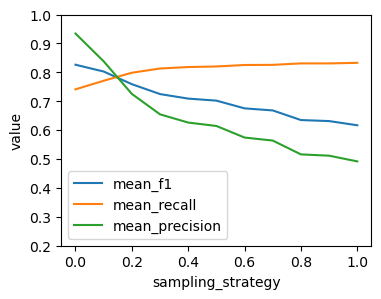

```python
import matplotlib.ticker as ticker

columns_plot = ['mean_f1','mean_recall','mean_precision']

fig, ax = plt.subplots(figsize=(4, 3))
for each in columns_plot:
    sns.lineplot(data = resultsSamplingStrategy, x = 'percentage', y = each, label = str(each))
ax.set(ylim=(0.2, 1))
plt.xlabel('sampling_strategy')
plt.ylabel('value')
plt.legend()
plt.show()
```

Se comprueba que el F1 score disminuye a medida que aumenta el número de datos sintéticos generados. Esto se debe a que al tener un mayor número de registros de la clase minoritaria, el modelo aprende mejor a clasificarla y por eso mejora el recall, en detrimiento de la precisión, ya que al cambiar la proporción asigna un mayor número de registros de la clase negativa como positiva. Como la disminución de la precisión es mayor que el aumento del recall, el F1 score disminuye.